# Observer analyses

Hannah, 9/19/2018

Data for Study 1 was collected in Fall 2015. Data for Study 2 was collected in Fall 2016.

**In Study 1:**  
- 101 subjects participated  
- 8 subjects’ AP data was discarded (see “Study1_badsubsAP.txt”)  
- 9 subjects’ WIT data was discarded (see “Study1_badsubsWIT.txt”)  
*This left 93 subjects with AP data and 92 subjects with WIT data.*

Additionally, IMS/EMS data is missing for subs 3, 27, 53, 82, 88, 89, 90, and 101.

**In Study 2:**  
- 206 subjects participated  
- 8 subjects’ AP data was discarded (see “Study2_badsubsAP.txt”)  
- 7 subjects’ WIT data was discarded (see “Study2_badsubsWIT.txt”)  
*This left 198 subjects with AP data and 199 subjects with WIT data.*

Additionally, IMS/EMS data is missing for 111, 189, and 201.

There were 48 trials for each condition in each task. In Study 2, each task was split into two sections so that participants could answer anxiety questions in the middle and end of each task.

### 1. Accuracy in each task:

#### 2 (Prime: Black/White) x 2 (Target: gun/tool or positive/negative) rANOVA

Only showing interaction indicating racial bias (Prime x Target). For calculation of effect sizes, see “7 Effect sizes.R”  
#### Study 1:  
**WIT**

```
##                      Df Sum Sq Mean Sq F value   Pr(>F)
## PrimeType:TargetType  1   2883  2882.9    96.5 5.97e-16 ***
## Residuals            91   2719    29.9
## ---
## Signif. codes:  0 '***' 0.001 '**' 0.01 '*' 0.05 '.' 0.1 ' ' 1
```

**AP**

```
##                      Df Sum Sq Mean Sq F value   Pr(>F)
## PrimeType:TargetType  1   1794  1794.3   39.82 9.63e-09 ***
## Residuals            92   4145    45.1
## ---
## Signif. codes:  0 '***' 0.001 '**' 0.01 '*' 0.05 '.' 0.1 ' ' 1
```

#### Study 2:

Only showing interaction indicating racial bias (Prime x Target). For calculation of effect sizes, see “7 Effect sizes.R”  
**WIT**

```
##                       Df Sum Sq Mean Sq F value Pr(>F)
## PrimeType:TargetType   1   3861    3861   120.7 <2e-16 ***
## Residuals            198   6331      32
## ---
## Signif. codes:  0 '***' 0.001 '**' 0.01 '*' 0.05 '.' 0.1 ' ' 1
```

**AP**

```
##                       Df Sum Sq Mean Sq F value   Pr(>F)
## PrimeType:TargetType   1   2478  2478.3   54.86 3.71e-12 ***
## Residuals            197   8900    45.2
## ---
## Signif. codes:  0 '***' 0.001 '**' 0.01 '*' 0.05 '.' 0.1 ' ' 1
```

### 2. Comparing accuracy across tasks

#### Study 1

Excludes subjects that don’t have data in both tasks (only includes sample of 90).

#### A. Correlation between performance bias scores on each task

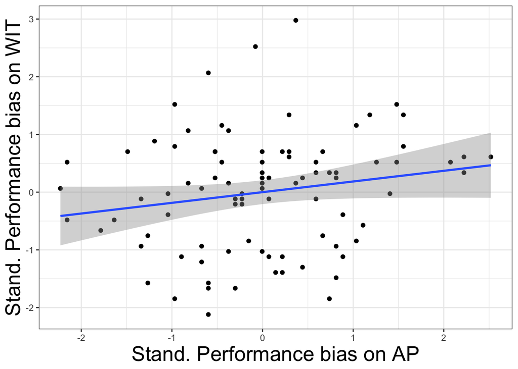

```
##
## Call:
## lm(formula = APStand ~ WITStand, data = s1.perfBias)
##
## Residuals:
##      Min       1Q   Median       3Q      Max
## -2.25273 -0.64697 -0.04138  0.68037  2.40625
##
## Coefficients:
##               Estimate Std. Error t value Pr(>|t|)
## (Intercept) -9.621e-17  1.042e-01   0.000   1.0000
## WITStand     1.851e-01  1.048e-01   1.767   0.0807 .
## ---
## Signif. codes:  0 '***' 0.001 '**' 0.01 '*' 0.05 '.' 0.1 ' ' 1
##
## Residual standard error: 0.9883 on 88 degrees of freedom
## Multiple R-squared:  0.03427,    Adjusted R-squared:  0.02329
## F-statistic: 3.123 on 1 and 88 DF,  p-value: 0.08068
```

#### B. Examine 3 way Prime x Target x Task interaction

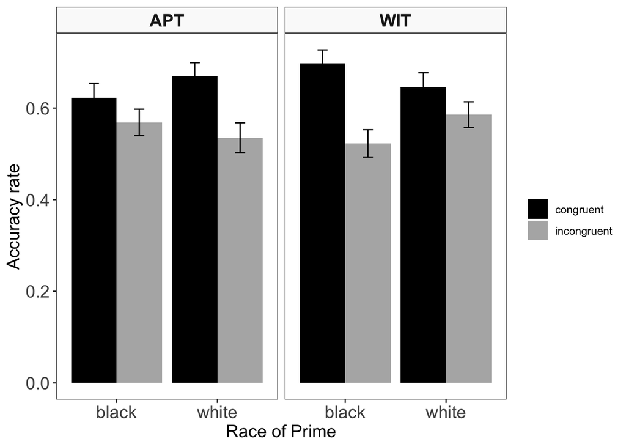

```
##                        Df Sum Sq Mean Sq F value   Pr(>F)
## PrimeType:ConType:Task  1    992   991.7   23.04 6.35e-06 ***
## Residuals              89   3830    43.0
## ---
## Signif. codes:  0 '***' 0.001 '**' 0.01 '*' 0.05 '.' 0.1 ' ' 1
```

#### A. Correlation between performance bias scores on each task

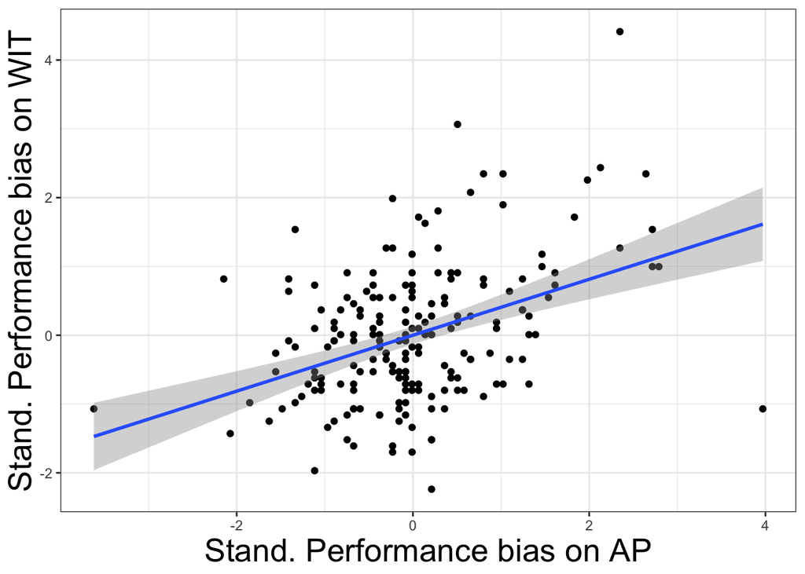

```
##
## Call:
## lm(formula = APStand ~ WITStand, data = s2.perfBias)
##
## Residuals:
##     Min      1Q  Median      3Q     Max
## -3.1856 -0.6008 -0.0491  0.5380  4.4047
##
## Coefficients:
##              Estimate Std. Error t value Pr(>|t|)
## (Intercept) 3.394e-16  6.594e-02   0.000        1
## WITStand    4.065e-01  6.611e-02   6.149 4.46e-09 ***
## ---
## Signif. codes:  0 '***' 0.001 '**' 0.01 '*' 0.05 '.' 0.1 ' ' 1
##
## Residual standard error: 0.916 on 191 degrees of freedom
## Multiple R-squared:  0.1653, Adjusted R-squared:  0.1609
## F-statistic: 37.82 on 1 and 191 DF,  p-value: 4.456e-09
```

#### B. Examine 3 way Prime x Target x Task interaction

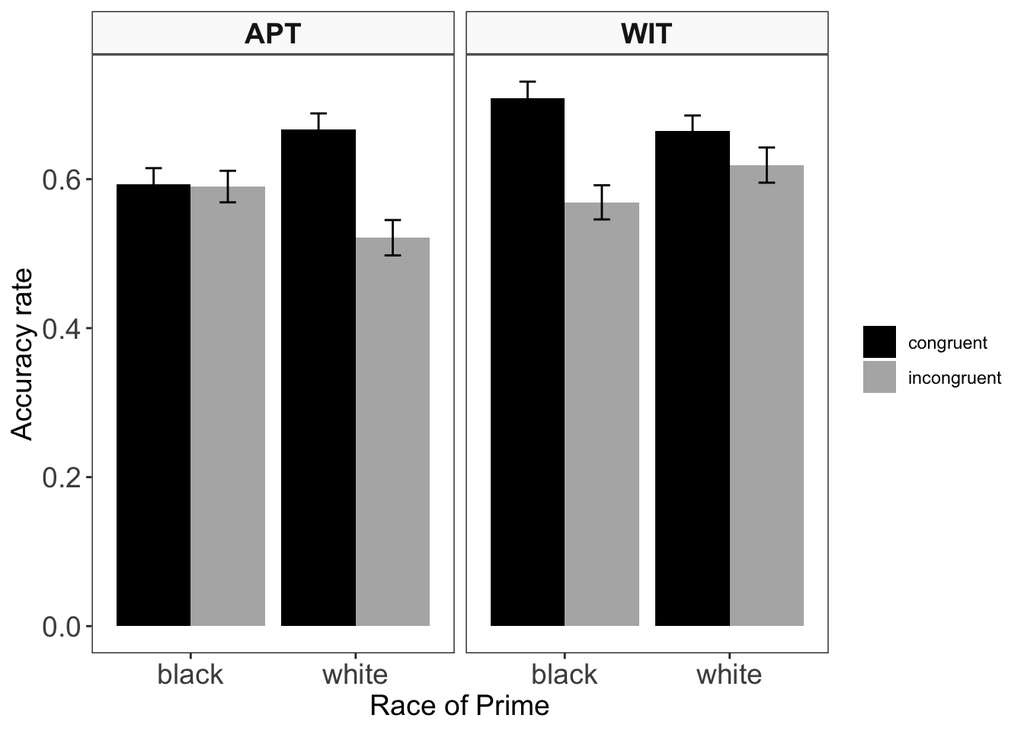

```
##                         Df Sum Sq Mean Sq F value Pr(>F)
## PrimeType:ConType:Task   1   3123  3123.3   94.02 <2e-16 ***
## Residuals              192   6378    33.2
## ---
## Signif. codes:  0 '***' 0.001 '**' 0.01 '*' 0.05 '.' 0.1 ' ' 1
```

### 3. Correspondance in PDP estimates across tasks

#### Study 1:

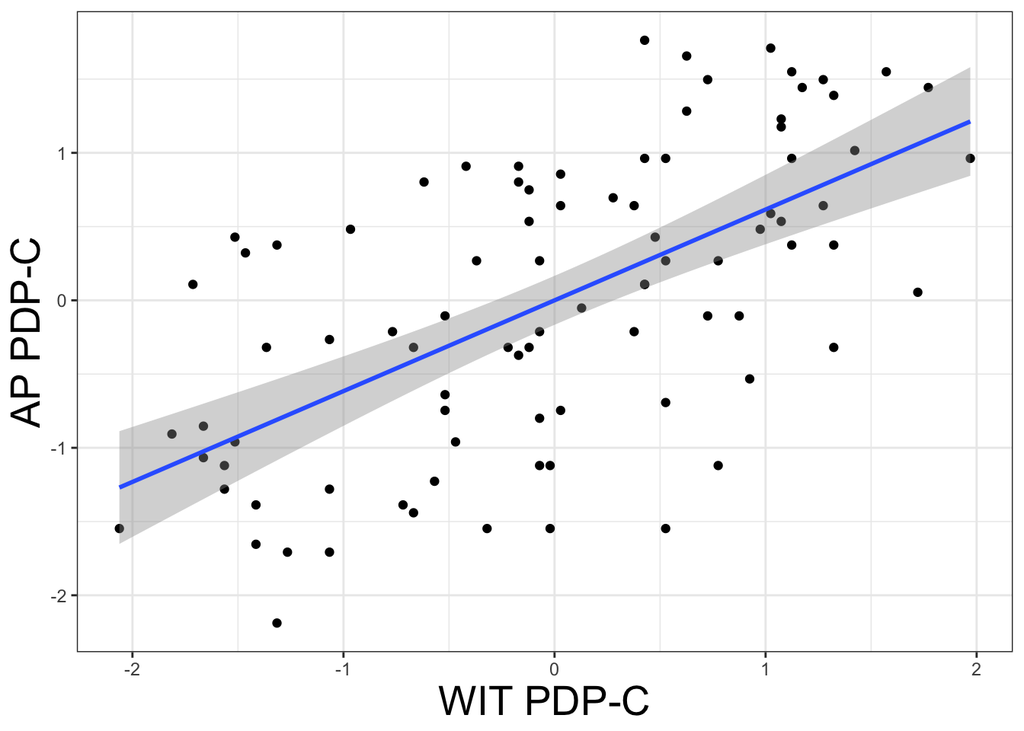

```
##
## Call:
## lm(formula = WIT_MeanC.stand ~ AP_MeanC.stand, data = s1.widePDP)
##
## Residuals:
##      Min       1Q   Median       3Q      Max
## -1.77991 -0.52543  0.04554  0.59056  1.68756
##
## Coefficients:
##                 Estimate Std. Error t value Pr(>|t|)
## (Intercept)    4.088e-16  8.353e-02   0.000        1
## AP_MeanC.stand 6.157e-01  8.400e-02   7.329 1.06e-10 ***
## ---
## Signif. codes:  0 '***' 0.001 '**' 0.01 '*' 0.05 '.' 0.1 ' ' 1
##
## Residual standard error: 0.7925 on 88 degrees of freedom
## Multiple R-squared:  0.379,  Adjusted R-squared:  0.372
## F-statistic: 53.72 on 1 and 88 DF,  p-value: 1.062e-10
```

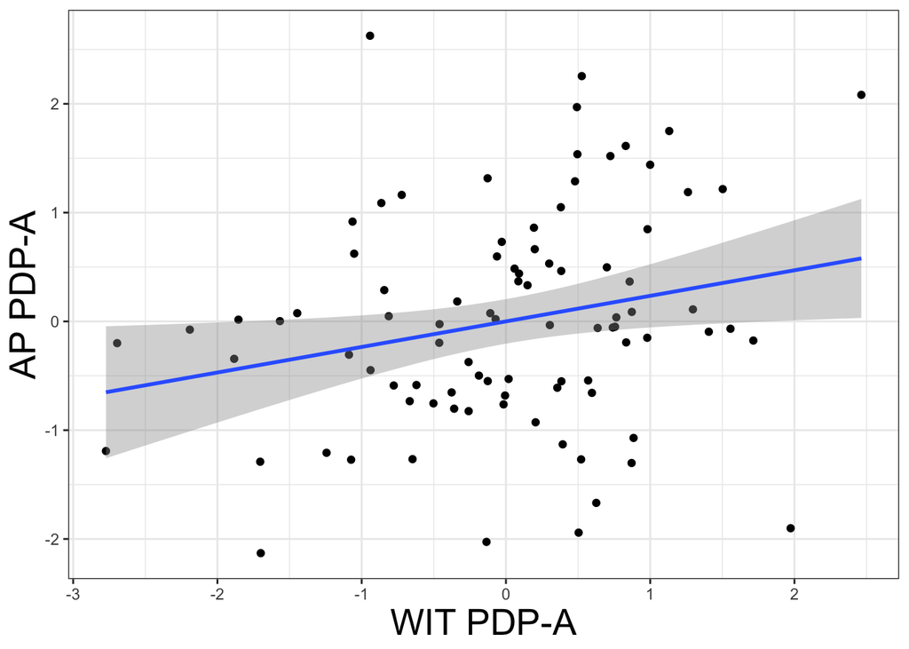

```
##
## Call:
## lm(formula = WIT_AResid.stand ~ AP_AResid.stand, data = s1.widePDP)
##
## Residuals:
##      Min       1Q   Median       3Q      Max
## -2.64807 -0.47586  0.03648  0.71495  2.42030
##
## Coefficients:
##                   Estimate Std. Error t value Pr(>|t|)
## (Intercept)     -9.771e-17  1.030e-01   0.000   1.0000
## AP_AResid.stand  2.349e-01  1.036e-01   2.267   0.0258 *
## ---
## Signif. codes:  0 '***' 0.001 '**' 0.01 '*' 0.05 '.' 0.1 ' ' 1
##
## Residual standard error: 0.9775 on 88 degrees of freedom
## Multiple R-squared:  0.05519,    Adjusted R-squared:  0.04445
## F-statistic:  5.14 on 1 and 88 DF,  p-value: 0.02583
```

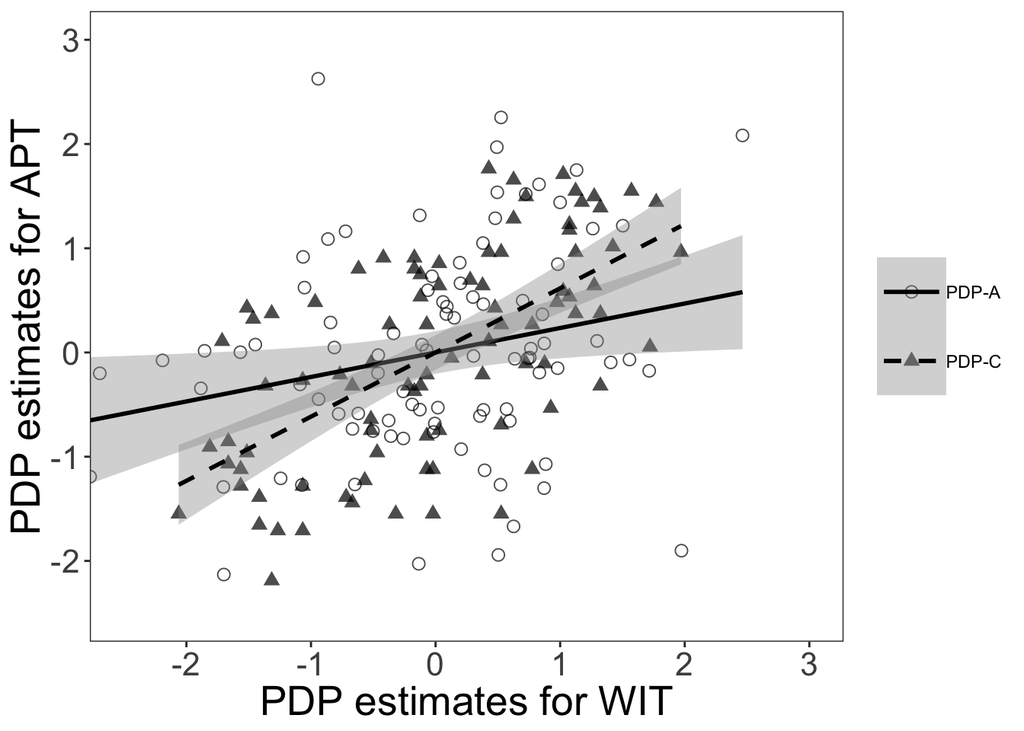

```
##
## Call:
## lm(formula = WITestimate ~ APTestimate * Type, data = compareAC)
##
## Residuals:
##      Min       1Q   Median       3Q      Max
## -2.64807 -0.49558  0.03792  0.65228  2.42030
##
## Coefficients:
##                         Estimate Std. Error t value Pr(>|t|)
## (Intercept)           -1.629e-16  9.380e-02   0.000  1.00000
## APTestimate            2.349e-01  9.432e-02   2.491  0.01368 *
## TypePDP-C              5.879e-16  1.326e-01   0.000  1.00000
## APTestimate:TypePDP-C  3.807e-01  1.334e-01   2.854  0.00483 **
## ---
## Signif. codes:  0 '***' 0.001 '**' 0.01 '*' 0.05 '.' 0.1 ' ' 1
##
## Residual standard error: 0.8898 on 176 degrees of freedom
## Multiple R-squared:  0.2171, Adjusted R-squared:  0.2038
## F-statistic: 16.27 on 3 and 176 DF,  p-value: 2.233e-09
```

#### Study 2:

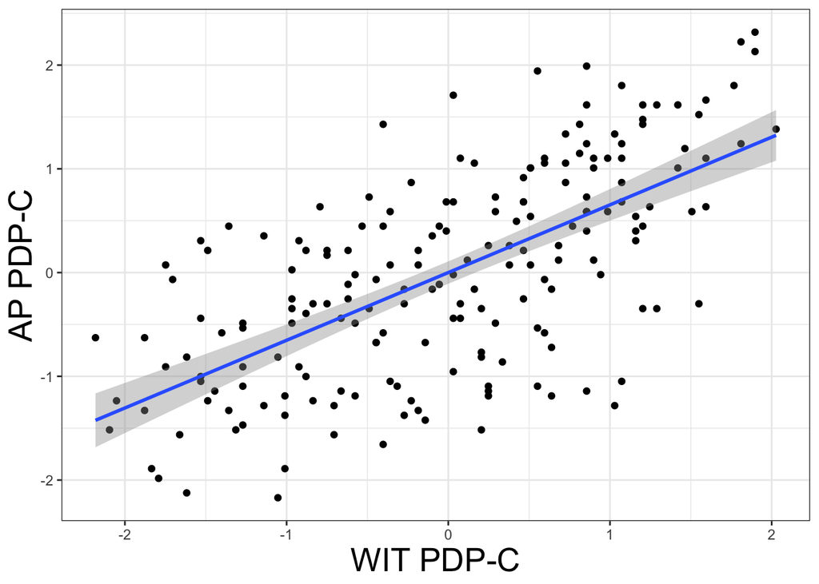

```
##
## Call:
## lm(formula = WIT_MeanC.stand ~ AP_MeanC.stand, data = s2.widePDP)
##
## Residuals:
##      Min       1Q   Median       3Q      Max
## -1.79597 -0.54572  0.03667  0.51197  1.86599
##
## Coefficients:
##                  Estimate Std. Error t value Pr(>|t|)
## (Intercept)    -1.645e-16  5.468e-02    0.00        1
## AP_MeanC.stand  6.527e-01  5.482e-02   11.91   <2e-16 ***
## ---
## Signif. codes:  0 '***' 0.001 '**' 0.01 '*' 0.05 '.' 0.1 ' ' 1
##
## Residual standard error: 0.7596 on 191 degrees of freedom
## Multiple R-squared:  0.426,  Adjusted R-squared:  0.423
## F-statistic: 141.7 on 1 and 191 DF,  p-value: < 2.2e-16
```

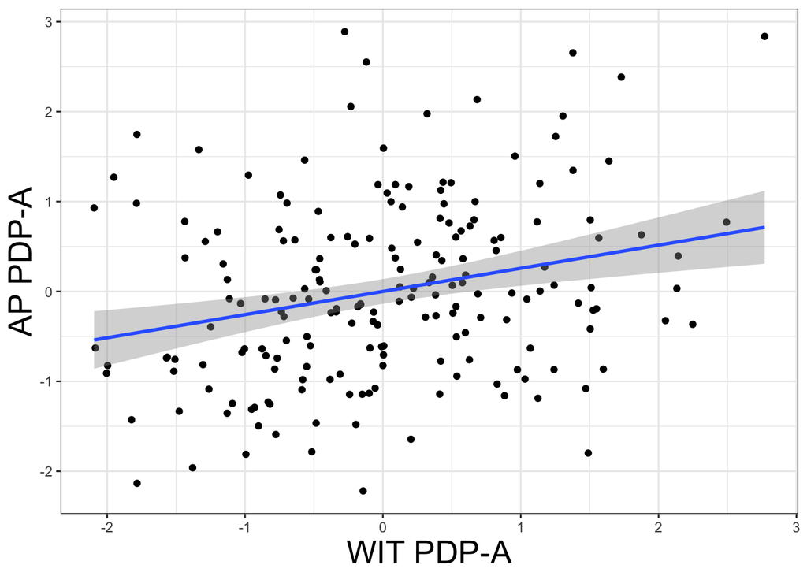

```
##
## Call:
## lm(formula = WIT_AResid.stand ~ AP_AResid.stand, data = s2.widePDP)
##
## Residuals:
##     Min      1Q  Median      3Q     Max
## -2.3346 -0.6315 -0.0074  0.6270  2.3417
##
## Coefficients:
##                  Estimate Std. Error t value Pr(>|t|)
## (Intercept)     1.869e-17  6.973e-02   0.000 1.000000
## AP_AResid.stand 2.577e-01  6.991e-02   3.685 0.000298 ***
## ---
## Signif. codes:  0 '***' 0.001 '**' 0.01 '*' 0.05 '.' 0.1 ' ' 1
##
## Residual standard error: 0.9688 on 191 degrees of freedom
## Multiple R-squared:  0.06639,    Adjusted R-squared:  0.0615
## F-statistic: 13.58 on 1 and 191 DF,  p-value: 0.0002975
```

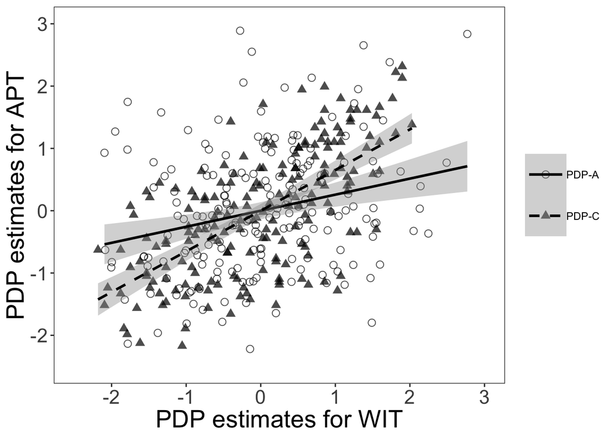

```
##
## Call:
## lm(formula = WITestimate ~ APTestimate * Type, data = compareAC)
##
## Residuals:
##      Min       1Q   Median       3Q      Max
## -2.33459 -0.57549  0.01939  0.57615  2.34165
##
## Coefficients:
##                         Estimate Std. Error t value Pr(>|t|)
## (Intercept)            8.660e-17  6.266e-02   0.000        1
## APTestimate            2.577e-01  6.282e-02   4.101 5.02e-05 ***
## TypePDP-C             -2.384e-16  8.861e-02   0.000        1
## APTestimate:TypePDP-C  3.950e-01  8.884e-02   4.446 1.15e-05 ***
## ---
## Signif. codes:  0 '***' 0.001 '**' 0.01 '*' 0.05 '.' 0.1 ' ' 1
##
## Residual standard error: 0.8705 on 382 degrees of freedom
## Multiple R-squared:  0.2462, Adjusted R-squared:  0.2403
## F-statistic: 41.59 on 3 and 382 DF,  p-value: < 2.2e-16
```

#### Study 1:

**Perf bias:**

```
##
## Call:
## lm(formula = perfBias ~ scale(IMS) * Observer * Task, data = s1.wide)
##
## Residuals:
##      Min       1Q   Median       3Q      Max
## -0.32724 -0.08750  0.00696  0.07369  0.34039
##
## Coefficients:
##                                    Estimate Std. Error t value Pr(>|t|)
## (Intercept)                         0.08494    0.01993   4.261 3.48e-05 ***
## scale(IMS)                         -0.01653    0.01789  -0.924    0.357
## ObserverPresent                     0.03277    0.02838   1.155    0.250
## TaskWIT                             0.04038    0.02819   1.433    0.154
## scale(IMS):ObserverPresent          0.01404    0.02952   0.476    0.635
## scale(IMS):TaskWIT                  0.02643    0.02530   1.045    0.298
## ObserverPresent:TaskWIT            -0.05267    0.04014  -1.312    0.191
## scale(IMS):ObserverPresent:TaskWIT -0.01665    0.04174  -0.399    0.691
## ---
## Signif. codes:  0 '***' 0.001 '**' 0.01 '*' 0.05 '.' 0.1 ' ' 1
##
## Residual standard error: 0.129 on 158 degrees of freedom
##   (14 observations deleted due to missingness)
## Multiple R-squared:  0.02364,    Adjusted R-squared:  -0.01962
## F-statistic: 0.5464 on 7 and 158 DF,  p-value: 0.7981
```

**PDP-C estimates:**

```
##
## Call:
## lm(formula = MeanC ~ scale(IMS) * Observer * Task, data = s1.wide)
##
## Residuals:
##      Min       1Q   Median       3Q      Max
## -0.42156 -0.15303  0.00446  0.15392  0.40765
##
## Coefficients:
##                                    Estimate Std. Error t value Pr(>|t|)
## (Intercept)                         0.36434    0.03161  11.528   <2e-16 ***
## scale(IMS)                          0.02567    0.02837   0.905    0.367
## ObserverPresent                     0.02062    0.04500   0.458    0.647
## TaskWIT                             0.01049    0.04470   0.235    0.815
## scale(IMS):ObserverPresent         -0.02852    0.04680  -0.609    0.543
## scale(IMS):TaskWIT                 -0.02693    0.04012  -0.671    0.503
## ObserverPresent:TaskWIT            -0.03646    0.06364  -0.573    0.568
## scale(IMS):ObserverPresent:TaskWIT  0.02990    0.06618   0.452    0.652
## ---
## Signif. codes:  0 '***' 0.001 '**' 0.01 '*' 0.05 '.' 0.1 ' ' 1
##
## Residual standard error: 0.2045 on 158 degrees of freedom
##   (14 observations deleted due to missingness)
## Multiple R-squared:  0.007558,   Adjusted R-squared:  -0.03641
## F-statistic: 0.1719 on 7 and 158 DF,  p-value: 0.9905
```

**PDP-A estimates:**

```
##
## Call:
## lm(formula = AResid ~ scale(IMS) * Observer * Task, data = s1.wide)
##
## Residuals:
##      Min       1Q   Median       3Q      Max
## -0.39653 -0.08999  0.00737  0.10244  0.35744
##
## Coefficients:
##                                      Estimate Std. Error t value Pr(>|t|)
## (Intercept)                         0.0028778  0.0232003   0.124   0.9014
## scale(IMS)                          0.0008643  0.0208251   0.042   0.9669
## ObserverPresent                     0.0143705  0.0330329   0.435   0.6641
## TaskWIT                             0.0236290  0.0328102   0.720   0.4725
## scale(IMS):ObserverPresent          0.0443437  0.0343520   1.291   0.1986
## scale(IMS):TaskWIT                  0.0272456  0.0294511   0.925   0.3563
## ObserverPresent:TaskWIT            -0.0721764  0.0467155  -1.545   0.1243
## scale(IMS):ObserverPresent:TaskWIT -0.1143868  0.0485810  -2.355   0.0198 *
## ---
## Signif. codes:  0 '***' 0.001 '**' 0.01 '*' 0.05 '.' 0.1 ' ' 1
##
## Residual standard error: 0.1501 on 158 degrees of freedom
##   (14 observations deleted due to missingness)
## Multiple R-squared:  0.06024,    Adjusted R-squared:  0.0186
## F-statistic: 1.447 on 7 and 158 DF,  p-value: 0.1903
```

**Probe interaction for PDP-A:**  
*Observer Present:*

```
##
## Call:
## lm(formula = AResid ~ scale(IMS) * Task, data = s1.wide[s1.wide$Observer ==
##     "Present", ])
##
## Residuals:
##      Min       1Q   Median       3Q      Max
## -0.39115 -0.09930  0.01505  0.10830  0.31012
##
## Coefficients:
##                    Estimate Std. Error t value Pr(>|t|)
## (Intercept)         0.01413    0.02355   0.600   0.5502
## scale(IMS)          0.03902    0.02370   1.647   0.1036
## TaskWIT            -0.04254    0.03331  -1.277   0.2053
## scale(IMS):TaskWIT -0.07522    0.03351  -2.244   0.0276 *
## ---
## Signif. codes:  0 '***' 0.001 '**' 0.01 '*' 0.05 '.' 0.1 ' ' 1
##
## Residual standard error: 0.1508 on 78 degrees of freedom
##   (8 observations deleted due to missingness)
## Multiple R-squared:  0.07884,    Adjusted R-squared:  0.04341
## F-statistic: 2.225 on 3 and 78 DF,  p-value: 0.09182
```

*Observer Absent:*

```
##
## Call:
## lm(formula = AResid ~ scale(IMS) * Task, data = s1.wide[s1.wide$Observer ==
##     "Absent", ])
##
## Residuals:
##      Min       1Q   Median       3Q      Max
## -0.39653 -0.08642 -0.00636  0.09551  0.35744
##
## Coefficients:
##                     Estimate Std. Error t value Pr(>|t|)
## (Intercept)        0.0029360  0.0230467   0.127    0.899
## scale(IMS)         0.0009669  0.0231851   0.042    0.967
## TaskWIT            0.0254624  0.0325930   0.781    0.437
## scale(IMS):TaskWIT 0.0304796  0.0327887   0.930    0.355
##
## Residual standard error: 0.1494 on 80 degrees of freedom
##   (6 observations deleted due to missingness)
## Multiple R-squared:  0.02973,    Adjusted R-squared:  -0.00665
## F-statistic: 0.8172 on 3 and 80 DF,  p-value: 0.4881
```

**Simple slopes:**

```
##
## Call:
## lm(formula = scale(AResid) ~ scale(IMS), data = s1.wide[s1.wide$Observer ==
##     "Present" & s1.wide$Task == "APT", ])
##
## Residuals:
##      Min       1Q   Median       3Q      Max
## -2.03036 -0.69571  0.04235  0.46939  2.09364
##
## Coefficients:
##             Estimate Std. Error t value Pr(>|t|)
## (Intercept)  0.03924    0.15036   0.261   0.7955
## scale(IMS)   0.26510    0.15223   1.741   0.0895 .
## ---
## Signif. codes:  0 '***' 0.001 '**' 0.01 '*' 0.05 '.' 0.1 ' ' 1
##
## Residual standard error: 0.9628 on 39 degrees of freedom
##   (4 observations deleted due to missingness)
## Multiple R-squared:  0.07215,    Adjusted R-squared:  0.04836
## F-statistic: 3.032 on 1 and 39 DF,  p-value: 0.0895
```

```
##
## Call:
## lm(formula = scale(AResid) ~ scale(IMS), data = s1.wide[s1.wide$Observer ==
##     "Present" & s1.wide$Task == "WIT", ])
##
## Residuals:
##     Min      1Q  Median      3Q     Max
## -2.2584 -0.4911  0.1650  0.6393  1.6146
##
## Coefficients:
##             Estimate Std. Error t value Pr(>|t|)
## (Intercept) -0.04591    0.14301  -0.321    0.750
## scale(IMS)  -0.21030    0.14478  -1.452    0.154
##
## Residual standard error: 0.9157 on 39 degrees of freedom
##   (4 observations deleted due to missingness)
## Multiple R-squared:  0.05132,    Adjusted R-squared:  0.02699
## F-statistic:  2.11 on 1 and 39 DF,  p-value: 0.1544
```

#### Study 2:

**Perf bias:**

```
##
## Call:
## lm(formula = perfBias ~ scale(IMS) * Observer * Task, data = s2.wide)
##
## Residuals:
##      Min       1Q   Median       3Q      Max
## -0.50280 -0.08169 -0.00663  0.07065  0.54777
##
## Coefficients:
##                                     Estimate Std. Error t value Pr(>|t|)
## (Intercept)                         0.060641   0.013124   4.621 5.28e-06 ***
## scale(IMS)                         -0.009008   0.012441  -0.724   0.4695
## ObserverPresent                     0.033258   0.019007   1.750   0.0810 .
## TaskWIT                             0.035551   0.018560   1.915   0.0562 .
## scale(IMS):ObserverPresent         -0.015943   0.019277  -0.827   0.4087
## scale(IMS):TaskWIT                 -0.010132   0.017594  -0.576   0.5650
## ObserverPresent:TaskWIT            -0.041370   0.026879  -1.539   0.1246
## scale(IMS):ObserverPresent:TaskWIT  0.027763   0.027261   1.018   0.3091
## ---
## Signif. codes:  0 '***' 0.001 '**' 0.01 '*' 0.05 '.' 0.1 ' ' 1
##
## Residual standard error: 0.1295 on 372 degrees of freedom
##   (6 observations deleted due to missingness)
## Multiple R-squared:  0.02733,    Adjusted R-squared:  0.009022
## F-statistic: 1.493 on 7 and 372 DF,  p-value: 0.1683
```

**PDP-C estimates:**

```
##
## Call:
## lm(formula = MeanC ~ scale(IMS) * Observer * Task, data = s2.wide)
##
## Residuals:
##      Min       1Q   Median       3Q      Max
## -0.54315 -0.18449  0.00456  0.17643  0.52030
##
## Coefficients:
##                                      Estimate Std. Error t value Pr(>|t|)
## (Intercept)                         0.3355554  0.0233887  14.347   <2e-16 ***
## scale(IMS)                          0.0402489  0.0221714   1.815   0.0703 .
## ObserverPresent                    -0.0003638  0.0338727  -0.011   0.9914
## TaskWIT                             0.0595237  0.0330767   1.800   0.0727 .
## scale(IMS):ObserverPresent         -0.0049051  0.0343541  -0.143   0.8865
## scale(IMS):TaskWIT                 -0.0110335  0.0313551  -0.352   0.7251
## ObserverPresent:TaskWIT             0.0228862  0.0479032   0.478   0.6331
## scale(IMS):ObserverPresent:TaskWIT -0.0113101  0.0485841  -0.233   0.8160
## ---
## Signif. codes:  0 '***' 0.001 '**' 0.01 '*' 0.05 '.' 0.1 ' ' 1
##
## Residual standard error: 0.2308 on 372 degrees of freedom
##   (6 observations deleted due to missingness)
## Multiple R-squared:  0.04264,    Adjusted R-squared:  0.02463
## F-statistic: 2.367 on 7 and 372 DF,  p-value: 0.02236
```

**PDP-A estimates:**

```
##
## Call:
## lm(formula = AResid ~ scale(IMS) * Observer * Task, data = s2.wide)
##
## Residuals:
##      Min       1Q   Median       3Q      Max
## -0.36792 -0.10848 -0.00114  0.09871  0.40961
##
## Coefficients:
##                                     Estimate Std. Error t value Pr(>|t|)
## (Intercept)                         0.010239   0.015469   0.662   0.5084
## scale(IMS)                         -0.027369   0.014664  -1.866   0.0628 .
## ObserverPresent                    -0.021538   0.022403  -0.961   0.3370
## TaskWIT                            -0.008138   0.021876  -0.372   0.7101
## scale(IMS):ObserverPresent          0.012201   0.022721   0.537   0.5916
## scale(IMS):TaskWIT                 -0.001259   0.020738  -0.061   0.9516
## ObserverPresent:TaskWIT             0.017688   0.031682   0.558   0.5770
## scale(IMS):ObserverPresent:TaskWIT -0.014986   0.032133  -0.466   0.6412
## ---
## Signif. codes:  0 '***' 0.001 '**' 0.01 '*' 0.05 '.' 0.1 ' ' 1
##
## Residual standard error: 0.1526 on 372 degrees of freedom
##   (6 observations deleted due to missingness)
## Multiple R-squared:  0.03425,    Adjusted R-squared:  0.01607
## F-statistic: 1.885 on 7 and 372 DF,  p-value: 0.07091
```